# Time Series Forecasting - Call Center

## Time Series Forecasting

```python
#Importing all the necessary packages for time series analysis,trivial data operations, computational analysis and forecasting.

import numpy as np # linear algebra
import pandas as pd # data processing, CSV file I/O (e.g. pd.read_csv)
import seaborn as sns
from datetime import datetime
from pandas import Series
import matplotlib.pyplot as plt
%matplotlib inline
sns.set(rc={'figure.figsize':(16.7,10)})

import datetime as dt
#from fbprophet import Prophet
# Statsmodels widely known for forecasting than Prophet
import statsmodels.api as sm
from scipy import stats
#from pandas.core import datetools
from plotly import tools
import chart_studio.plotly as py
import plotly.figure_factory as ff
import plotly.tools as tls
import plotly.graph_objs as go
from plotly.offline import download_plotlyjs, init_notebook_mode, plot, iplot
init_notebook_mode(connected=True)
import warnings
```

## *Data Analysis and Interpretation*

The goal of this project is to forecast the number of calls on the daily basis for a month. Therefore it is equally important to analyse and interpret the data according to every aspect of time series analysis including the monthly, daily, weekly and yearly changes with respect to time. By this analysis, more robust features for the model can be identified and certain patterns in the nature of problem based on this dataset can be extracted.

```python
#Importing dataset

data = pd.read_csv("HistorieDaten - Report.csv")

print(data.head())
print("________________________DATA TYPES_________________________")

print(data.dtypes)

print("________________________DATAFRAME SHAPE____________________")
print(data.shape)
```

```
                  From  Offered_Calls
0  01.01.2012 00:15:00            1.0
1  01.01.2012 00:30:00            2.0
2  01.01.2012 01:30:00            1.0
3  01.01.2012 03:00:00            1.0
4  01.01.2012 03:45:00            2.0
________________________DATA TYPES_________________________
From              object
Offered_Calls    float64
dtype: object
________________________DATAFRAME SHAPE____________________
(211395, 2)
```

```python
#Changing datatype of Datetime to Datetime

data.columns = ['Datetime', 'Count']
data.Datetime = pd.to_datetime(data.Datetime,format='%d.%m.%Y %H:%M:%S')
data.dtypes
```

```
Datetime    datetime64[ns]
Count              float64
dtype: object
```

```python
# Segregating the dataset with respect to year, day, month, hour and day_of_week to make the analysis and visualizations

i = 0
year=[]
day =[]
month=[]
hour=[]
day_of_week=[]

while i < data.shape[0]:
    temp = data.iloc[i,0]
    year.append(temp.year)
    month.append(temp.month)
    day.append(temp.day)
    hour.append(temp.hour)
    day_of_week.append(temp.dayofweek)
    i +=1
train = data
train["year"] = year
train["month"]= month
train["day of week"]= day_of_week
train["day"] = day
train["hour"]= hour
```

```python
# This is how the dataframe has become now which will help to better analyze and intrepret the data.

train.head()
```

|  | Datetime | Count | year | month | day of week | day | hour |
| --- | --- | --- | --- | --- | --- | --- | --- |
| 0 | 2012-01-01 00:15:00 | 1.0 | 2012 | 1 | 6 | 1 | 0 |
| 1 | 2012-01-01 00:30:00 | 2.0 | 2012 | 1 | 6 | 1 | 0 |
| 2 | 2012-01-01 01:30:00 | 1.0 | 2012 | 1 | 6 | 1 | 1 |
| 3 | 2012-01-01 03:00:00 | 1.0 | 2012 | 1 | 6 | 1 | 3 |
| 4 | 2012-01-01 03:45:00 | 2.0 | 2012 | 1 | 6 | 1 | 3 |

### *The total Average of calls per year*

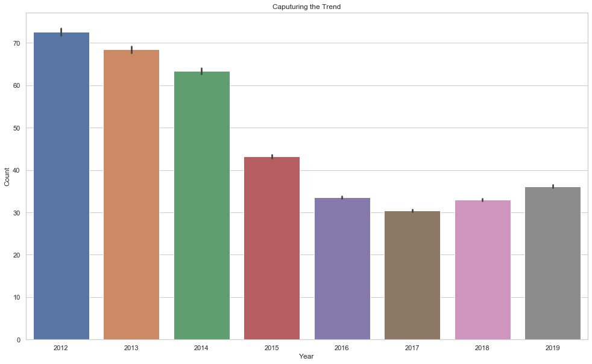

```python
graph = pd.DataFrame()
graph['Count'] = train.Count
graph['Year'] = train.year
sns.set_style("whitegrid")
ax = sns.barplot(x="Year", y="Count", data=graph ).set_title("Caputuring the Trend")
```

It can be observed that the number of calls are decreasing as per the time increases per year. But it has started increasing again from 2017.

### *The total Average of calls per month*

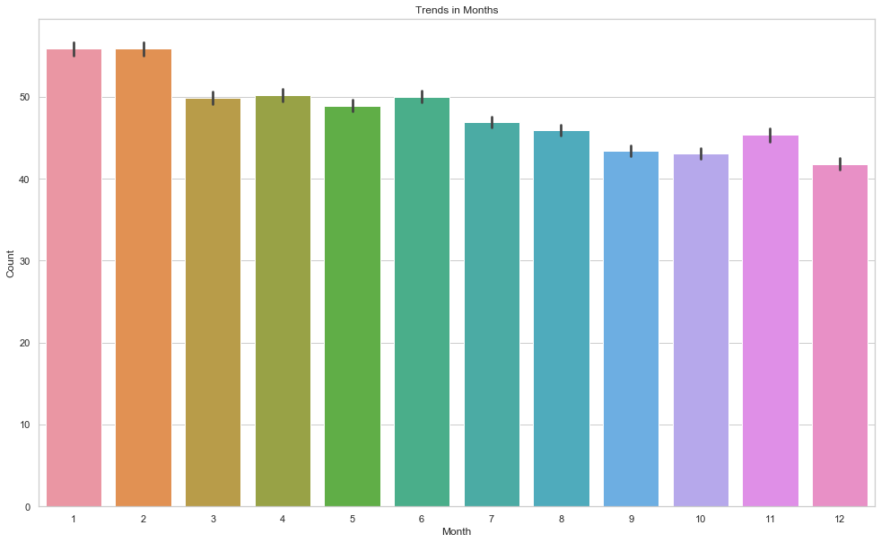

```python
graph = pd.DataFrame()
graph['Count'] = train.Count
graph['Month'] = train.month

sns.set_style("whitegrid")
ax = sns.barplot(x="Month", y="Count", data=graph).set_title("Trends in Months")
```

There is not much trend to be followed looking at the monthly data, but we can observe that the average number of calls in JAN and FEB are slightly higher looking at the data from 2012 - 2019.

### *The total Average of calls per day of the month*

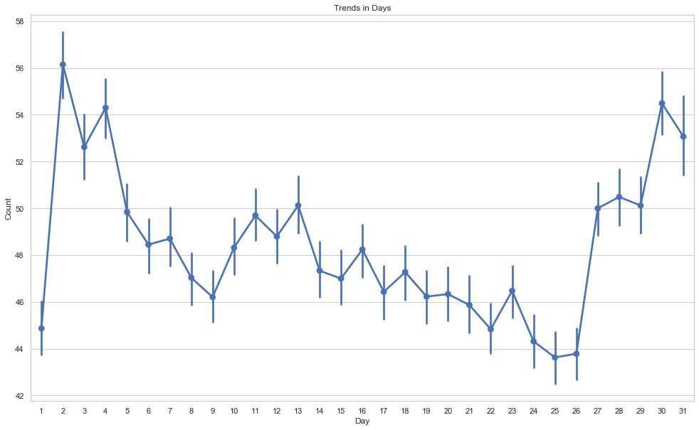

```python
graph = pd.DataFrame()
graph['Count'] = train.Count
graph['Day'] = train.day

sns.set_style("whitegrid")
ax = sns.pointplot(x="Day", y="Count", data=graph).set_title("Trends in Days")
```